# Introduction to Networks and Python

**Blas Kolic, 2025**

Welcome to the Networks Workshop for the uc3m PhD program on Social Sciences! I hope you find this course useful and gain knowledge and experience with Python and Network Theory applied to the Social Sciences :). If you have problems setting up Python, find a set of instructions at [`python_setup.md`](https://blas-ko.github.io/uc3m_networks_workshop_2025/python_setup.md) in the course repository.

### Introduction to Python and Jupyter Notebooks

Python is a very popular **high-level programming language**. If you have never programmed before, you can think of programming as using a very powerful calculator, one that works not only with numbers but with any kind of *object* a computer can represent. These objects include numbers, of course, but also words or characters (called **strings**), lists, matrices, functions, dictionaries, and even custom-made structures such as **networks**.

Python runs code by reading a sequence of instructions written in a text file known as a **script**. In this workshop, however, we will primarily work with **Jupyter Notebooks**, which offer a more interactive and beginner-friendly environment.

A **Jupyter Notebook** is an interactive workspace where you can run code, write notes, and explore data—similar to notebooks in [RStudio](https://posit.co/download/rstudio-desktop/). A notebook is divided into **cells**. Some cells contain Python code that you can execute independently, while others contain text written in **Markdown** (like the cell you are reading now). This setup makes notebooks ideal for learning, experimenting, and documenting your work all in one place.

Like any calculator, Python’s basic functionality can be extended through **packages** (also called *libraries*). These are add-ons written by others to provide specific features that are not built into core Python. For example, the package `matplotlib` allows us to create plots and visualize data. Unlike app-store plugins, Python packages are free and widely shared within the community. In this first tutorial, we will cover the basics of programming in Python and introduce a few essential packages for data and network analysis:

- **NumPy** – for working with numerical data and arrays
- **Pandas** – for reading, saving and handling datasets in table form
- **Matplotlib** – for plotting and visualizing data
- **NetworkX** – the most widely used Python library for analyzing networks

By the end, you’ll have a foundation strong enough to dive into network analysis and the more advanced tools used throughout the workshop.

**Outline of the tutorial**

1. **Simple operations**: Learn the basic python operations, starting from using it as a calculator to handling different types
2. **Functions**: Learn how to use built-in functions as well to define your own
3. **Control flow**: Learn the basics of `if-else` blocks and `for` loops.
4. **Importing libraries**: Learn to import python libraries/packages for extra functionalities
5. **Basic network analysis with `networkx`**: Import library `networkx` to construct a network and perform a basic analysis.

### Jupyter notebook basics

Before we begin, here are a few **Jupyter Notebook basics** that will help you move smoothly through the tutorial.

A Jupyter Notebook is organized into **cells**, and each cell can be either:

- a **Code cell** (where you write and run Python code), or
- a **Markdown cell** (where you write formatted text, notes, or explanations).

You can switch a cell’s type using the toolbar at the top, or with keyboard shortcuts:

- **`Esc` → `M`** to turn a cell into Markdown
- **`Esc` → `Y`** to turn it into Code

To **run a cell**, press:

- **Shift + Enter** — runs the cell and moves to the next one
- **Ctrl + Enter** — runs the cell but stays in place

You can **add new cells** from the toolbar or using:

- **`Esc` → `A`** to insert a cell *above*
- **`Esc` → `B`** to insert a cell *below*
- **`Esc` → `C`** to copy a selected cell
- **`Esc` → `X`** to cut a selected cell
- **`Esc` → `V`** to paste the copied cell below

To **delete a cell**, press:

- **`Esc` → `D` → `D`** (press `D` twice)

A few helpful tips:

- Jupyter keeps track of the order in which you run cells. If something behaves oddly, you can use the **Kernel → Restart** option to reset the environment and run your cells again in order.
- You can see a cell’s output immediately below it—great for experimenting interactively.
- Markdown cells let you create titles, lists, equations, code snippets, and more, making notebooks excellent for combining analysis and explanation.

These simple commands will make the notebook environment feel much more intuitive as we go along.

## 1. Simple operations

```python
# Comments can be added using the hash symbol (#), these do not affect the code execution.

# First, let's perform a simple arithmetic operation.
3 + 4
```

```
7
```

```python
# We can perform all the basic arithmetic operations:
3*5 - 2*(11/4 - 1) + 10**2  # Multiplication (*), division (/), addition (+), subtraction (-), and exponentiation (**).
```

```
111.5
```

We can even *store* values with whatever name we want

```python
# Store values 3 and 4 into variables x and y
x = 3
y = 4
x + y
```

```
7
```

The good thing is that these variables (`x` and `y`) can be used wherever we want, not only in the cell they were defined.

```python
# Create a new variable z that is the sum of x and y as before, and then return the square of z
z = x + y
z**2
```

```
49
```

Anything can be stored into a variable, not only numbers. Python can handle objects with different types, such as lists, strings, or dictionaries. This is when things start getting useful.

```python
# Lists can be created using square brackets
X = [10, 20, 30]
Y = [4, 5, 6]
S = ["apple", "banana", "coconut"] # Lists can also contain strings (marked with quotes (" or '))
M = [1, "b", True] # Lists can even contain mixed types (numbers, strings, booleans, etc.)

# We can get elements of a list by indexing (starting from 0)
X[0] # Get the first element of list X
```

```
10
```

```python
# We can also append elements to a list using the .append() method
X.append(40) # Append the value 40 to the end of list X
X  # Now list X contains [10, 20, 30, 40]
```

```
[10, 20, 30, 40]
```

```python
# We can print values using the print() command so we don't have to rely on the last line of a cell.
print(X[0]) # Print the first element of list X
print(Y[1]) # Print the second element of list S
print(X[0] + Y[1]) # Print the sum of the first element of X and the second element of Y

# Printing multiple values in one print statement using commas can be very useful
print("First element of X:", X[0])
print("Second element of Y:", Y[1])
print("Sum of values:", X[0] + Y[1])

# We can even embed expressions directly within f-strings for formatted output (using the prefix 'f' before the string)
print(f"The sum of the first element of X ({X[0]}) and the second element of Y ({Y[1]}) is {X[0] + Y[1]}.")
```

```
10
5
15
First element of X: 10
Second element of Y: 5
Sum of values: 15
The sum of the first element of X (10) and the second element of Y (5) is 15.
```

```python
# Another important object type are dictionaries. They are similar to lists, but instead of using integer indices, they use keys to access values.
D = {"name": "Alice", "age": 30, "city": "New York"} # Create a dictionary (with {}) with keys "name", "age", and "city"
print(D["name"]) # Access the value associated with the key "name"

# Similar to lists, we can add new key-value pairs to a dictionary
D["occupation"] = "Engineer" # Add a new key "occupation" with value "Engineer"
print(D) # Now the dictionary D contains the new key-value pair

# Dictionaries have many useful methods, such as .keys() and .values()
print("Keys:", D.keys()) # Print all keys in the dictionary D
print("Values:", D.values()) # Print all values in the dictionary D
```

```
Alice
{'name': 'Alice', 'age': 30, 'city': 'New York', 'occupation': 'Engineer'}
Keys: dict_keys(['name', 'age', 'city', 'occupation'])
Values: dict_values(['Alice', 30, 'New York', 'Engineer'])
```

## 2. Functions

As we saw above, we used a command called `print` that displays the result of whatever operation we perform. This is an example of a **Python function**.

Functions are useful because they let us perform operations on Python objects in a clean and consistent way. Instead of writing long sequences of instructions over and over, we can rely on functions as shortcuts for common tasks. This becomes especially helpful when working with data, where we often need to transform, combine, or inspect objects repeatedly.

Python includes many built-in functions that are worth knowing from the start:

| Function | What it does | Example |
| --- | --- | --- |
| `print()` | Shows output on the screen | `print("Hello")` |
| `type()` | Tells you the type of an object | `type(3.14)` |
| `len()` | Gives the length of a list or string | `len("network")` |
| `sum()` | Adds elements of a list | `sum([1, 2, 3])` |
| `max()`, `min()` | Find the largest or smallest value | `max([4, 9, 1])` |
| `round()` | Rounds numbers | `round(3.14159, 2)` |
| `range()` | Generates a sequence of integers | `list(range(5))` |

```python
# For example, let's take the sum, length, and maximum value of list X
print("Sum of X:", sum(X))
print(f"The list X={X} has {len(X)} elements.")
print(f"The maximum value in list X is {max(X)}.")
```

```
Sum of X: 100
The list X=[10, 20, 30, 40] has 4 elements.
The maximum value in list X is 40.
```

We can access the documentation of a function by putting `?` before the function name (this can be very useful!)

```python
?len
```

```
Signature: len(obj, /)
Docstring: Return the number of items in a container.
Type:      builtin_function_or_method
```

We can even create *our own custom functions*!

To do so, we add the prefix `def`, followed by the function name and parentheses containing any input parameters. The function contents (or body) is indented below.

```python
# Let's create a simple function that takes the returns the square of a number.
def square(x):
    "Returns the square of number x" # (Optional) This is a docstring that describes what the function does
    return x * x # The return statement specifies the output of the function

square(5)  # Call the function with input 5, should return 25
```

```
25
```

```python
# We can check access the documentation of our own functions too!
?square
```

```
Signature: square(x)
Docstring: Returns the square of number x
File:      /var/folders/qh/_f830_690v705d804ksqlkjh0000gn/T/ipykernel_2534/553279548.py
Type:      function
```

```python
# The output of a function can be stored in a variable for later use
x = 10
x_squared = square(x)
print(f"The square of {x} is {x_squared}.")
```

```
The square of 10 is 100.
```

```python
# Functions can also take multiple arguments
def divide(a, b):
    "Returns the division of a by b"
    return a / b

divide(3, 4)  # Call the divide function with inputs 3 and 4, should return 0.75
```

```
0.75
```

```python
# And we can even have default argument values
def power_over_two(base, exponent=2):
    "Returns base raised to the power of exponent (default is 2) and divided by 2"
    power = base ** exponent # We can define intermediate variables inside functions
    return power / 2

x = 4
print("Squared:", power_over_two(x))      # Uses default exponent of 2, should return 8.0
print("Cubed:", power_over_two(x, 3))   # Uses exponent of 3, should return 32.0
```

```
Squared: 8.0
Cubed: 32.0
```

### Dealing with types and objects

```python
# We can check the type of an object using the type() function
type(X), type(D), type(x), type(3.14159)  # Lists, dictionaries, numbers, are all different types of objects
```

```
(list, dict, int, float)
```

```python
# We can check the type of any object, including functions!
type(len)
```

```
builtin_function_or_method
```

Objects of different types may have their own associated functions, called *methods*.

You can check the available methods by pressing dot (`.`) after the object name and then pressing the `TAB` key.

```python
# For example, let's take the string 'hello' and make it uppercase
s = 'hello'
print(type(s))  # This should show that s is of type 'str' (string)

# objects of type string have their own associated functions (called methods)
print(s.upper())  # Call the upper() method of string objects to convert to uppercase
```

```
<class 'str'>
HELLO
```

```python
# Lists, for instance, also have their own methods
# We have previously used the append() method to add elements to a list
L = [3, 1, 4, 1, 5]
L.sort()  # Call the sort() method of list objects to sort the list in place
print("Sorted list:", L)  # Now L should be [1, 1, 3, 4, 5]
```

```
Sorted list: [1, 1, 3, 4, 5]
```

#### Handling errors

Knowing how to read errors is crucial for debugging your code. The last line of the error message usually indicates the type of error.

```python
# There are certain types that work well together, such as integers and floats
print("Sum of an integer with a float:", 3 + 4.12)

# But some of them don't, such as strings and numbers, which may result in an error
print("Sum of a string with a number gives an error:")
"three" + 4
```

```
Sum of an integer with a float: 7.12
Sum of a string with a number gives an error:
```

```
---------------------------------------------------------------------------
TypeError                                 Traceback (most recent call last)
Cell In[20], line 6
      4 # But some of them don't, such as strings and numbers, which may result in an error
      5 print("Sum of a string with a number gives an error:")
----> 6 "three" + 4

TypeError: can only concatenate str (not "int") to str
```

```python
# We can get error even in our own functions
divide(5, 0)  # This will raise a ZeroDivisionError, which is a different type of error
```

```
---------------------------------------------------------------------------
ZeroDivisionError                         Traceback (most recent call last)
Cell In[21], line 2
      1 # We can get error even in our own functions
----> 2 divide(5, 0)  # This will raise a ZeroDivisionError, which is a different type of error

Cell In[14], line 4, in divide(a, b)
      2 def divide(a, b):
      3     "Returns the division of a by b"
----> 4     return a / b

ZeroDivisionError: division by zero
```

## 3. Control Flow

When writing code, we often want our program to make decisions or repeat certain actions. This is where **control flow** comes in. Control flow tools allow Python to decide *what to do next* based on conditions or to repeat tasks automatically. Two of the most common tools are **`if` statements** and **`for` loops**.

### `if` statements: making decisions

An `if` statement lets your code run only when a certain condition is true.  
You can think of it as setting rules:

> *If something happens, then do this. Otherwise, do something else.*

The usual Python if-statement block looks something like

```
if condition:
    # do something
else:
    # Do something else
```

```python
# For example, let's use an if statement to check the temperature and print a message accordingly.
temperature = 32

if temperature > 30:
    print("It's hot outside!")
else:
    print("The temperature is fine.")


# The statement `temperature > 30` is a Boolean (True or False), which evaluates whether the if condition is met.
temperature > 30, type(temperature > 30)
```

```
It's hot outside!
```

```
(True, bool)
```

### `for` loops: repeating actions

A `for` loop lets you repeat the same action for each element in a sequence (like a list, string, or range of numbers). Think of it as telling Python:

> Repeat this operation for every item in this collection.

The usual Python for-loop block looks something like

```
for element in sequence:
    # do something with `element`
```

```python
# For example, let's use a for loop to iterate over a list of fruits and print a message for each fruit.
fruits = ["apples", "bananas", "pears"]

# Do some operation for each fruit in the list
for fruit in fruits:
    print(f"I like {fruit}.")

# We can also get the index of each fruit using the enumerate() function
for i, fruit in enumerate(fruits):
    print(f"Fruit {i}: {fruit}")
```

```
I like apples.
I like bananas.
I like pears.
Fruit 0: apples
Fruit 1: bananas
Fruit 2: pears
```

We can combine all these concepts to create tailored complex behaviors

Here's a simple function that uses variable naming, `if` statements, and `for` loops to analyze a very small social network.

Imagine we represent friendships using a **dictionary**, where each person is linked to a list of their friends. This is very similar to how real networks are stored in datasets.

```python
# A small friendship network represented as a dictionary
# Each person says who their friends are.
friendships = {
    "Alice":   ["Bob", "Clara"],
    "Bob":     ["Alice", "Daniel", "Eva"],
    "Clara":   ["Alice"],
    "Daniel":  ["Bob"],
    "Eva":     ["Alice"]
}
```

```python
def consider_as_friend(friendships, person): # define function
    """Return all people who say that `person` is their friend. """ # add docstring

    person_friends = []  # initialize list of people who consider `person` a friend

    for other in friendships: # for loop
        if person in friendships[other]: # if statement
            person_friends.append(other) # call a method of the list object

    return person_friends

consider_as_friend(friendships, "Bob")  # Who considers Alice a friend?
```

```
['Alice', 'Daniel']
```

```python
# Exercise 1: write a function that gives the most popular person in the network (the one who is considered a friend by the most people).
# Tip: you can use the `consider_as_friend()` function defined above.
def most_popular(friendships):
    """Return the person who is considered a friend by the most people."""

    # Initialize variables to track the most popular person and the highest count
    most_popular_person = None # None defined an empty variable
    popularity = 0

    # Write your code here
```

## 4. Importing libraries

As we said before, libraries are like plugins that extend the functionality of core Python.

There are two main ways to import libraries. The first way looks something like

```
import numpy as np
```

Here, we're importing library `numpy` and will call it with the shorthand name `np`. We can use `np` to methods from numpy.

The second way involves importing specific methods from a library, something like

```
from numpy import mean
```

Here, we import the `mean` method from numpy, which we can call as an ordinary function.

### 4.1. NumPy

**NumPy** is one of the core libraries in the Python scientific ecosystem. It is very fast and designed for working with numerical data, especially **lists**, **arrays**, **matrices**, and general **linear algebra** tasks.

At first, NumPy may feel a bit confusing because it introduces its own data structure called the **NumPy array** (`numpy.ndarray`). Although it looks similar to the regular Python lists we saw earlier, it behaves differently and is optimized for mathematical operations. Once you get used to it, NumPy becomes an essential tool for any data or network analysis workflow.

Here are the most important things to know when starting with NumPy:

- **NumPy arrays behave like “mathematical vectors.”**  
  You can add, subtract, multiply, or apply functions to them element-wise with very simple syntax.
- **You can easily create arrays** from Python lists, ranges, or even automatically using functions like `np.zeros()`, `np.ones()`, or `np.arange()`.
- **NumPy provides fast linear algebra tools**, such as matrix multiplication, dot products, transposes, and more.
- **NumPy arrays support slicing and indexing**, which let you extract specific portions of your data (similar to lists, but more powerful).

```python
import numpy as np  # This imports the whole numpy library under shorthand name np
from numpy import mean # This imports only the mean function from the numpy library
```

```python
# We can use the `mean` function directly to compute the average of a list of numbers
data = [10, 20, 30, 40, 50]
mean(data)
```

```
np.float64(30.0)
```

```python
# We can do exactly the same by calling the mean method from the numpy library
np.mean(data)
```

```
np.float64(30.0)
```

```python
# However, numpy shines when we work with its own data structures, such as numpy arrays.
data = np.array(data) # Convert the regular Python list to a numpy array
data # The numpy array looks similar to a regular list, but it has different properties and methods
```

```
array([10, 20, 30, 40, 50])
```

```python
# We can slice numpy arrays to get specific elements or ranges

# Simlar to lists, we can get specific elements using indexing
print(data[0]) # Get the first element of the numpy array
# We can also slice arrays to get a range of elements (format is start:stop)
print(data[1:4]) # Get elements from index 1 to 3 (4 is excluded)
```

```
10
[20 30 40]
```

```python
# Here are some examples of performing some mathematical operations with numpy arrays:
print("Original data:", data)
print("Add 100:", data + 100) # You can add a number to the array
print("Multiply by 3:", data * 3)   # You can multiply the array by a number
print("Add two arrays (element-wise):", data + data) # You can add two arrays element-wise
# Arrays also have their own methods
print("Mean of data:", data.mean())  # Compute the mean using the array's method
print("Standard deviation of data:", data.std())  # Compute the standard deviation
```

```
Original data: [10 20 30 40 50]
Add 100: [110 120 130 140 150]
Multiply by 3: [ 30  60  90 120 150]
Add two arrays (element-wise): [ 20  40  60  80 100]
Mean of data: 30.0
Standard deviation of data: 14.142135623730951
```

```python
# numpy also handles matrices, which are just 2-dimensional arrays.
A = np.array([[1, 2],
              [3, 4]])
B = np.array([[2, 0],
              [1, 2]])

C = A @ B # matrix multiplication (using the @ operator)
D = A * B # element-wise multiplication
print("C:", C)
print("D:", D)

# We can also check the shape of an array (number of rows and columns)
print("Shape of A:", A.shape)

# We can compute statistics along specific axes (rows or columns)
print("By-column mean:", A.mean(axis=0))  # Mean of each column
print("By-row mean:", A.mean(axis=1))  # Mean of each row
```

```
C: [[ 4  4]
 [10  8]]
D: [[2 0]
 [3 8]]
Shape of A: (2, 2)
By-column mean: [2. 3.]
By-row mean: [1.5 3.5]
```

`numpy` also handles random numbers and distributions.

To generate random numbers, we can use numpy's random module, which is called as a method of the numpy library.

```python
# Generate a list of random numbers
print(np.random.rand(5))  # Generate 5 random numbers from a uniform distribution over [0, 1)
# Generate a 10x10 array of random numbers from a normal distribution with mean 0 and standard deviation 1
rand_matrix = np.random.randn(10, 10)

# The random matrix should have a mean close to 0 and standard deviation close to 1
print("Mean of random matrix:", rand_matrix.mean().round(2))
print("Standard deviation of random matrix:", rand_matrix.std().round(2))
```

```
[0.86561823 0.47683465 0.79276418 0.07578955 0.03541471]
Mean of random matrix: -0.04
Standard deviation of random matrix: 0.93
```

### 4.2. Pandas

**Pandas** is one of the most important Python libraries for working with data. It allows you to load, explore, clean, and manipulate datasets in a way that feels similar to working with Excel or R data frames, but with the power and flexibility of Python.

The main structure in pandas is the **DataFrame**, which you can think of as a table: rows represent observations, and columns represent variables. Pandas makes it extremely easy to:

- convert arrays (from numpy or Python lists) into DataFrame objects
- load data from CSV, Excel, or other formats
- explore and summarize variables
- select and filter rows
- create or transform new columns
- handle missing data
- group and aggregate information

If we want to **convert existing data** (say, from a list or matrix `X`) into a DataFrame, we can use

```
  pd.DataFrame(X)
```

The `DataFrame` method has a lot of optional arguments (such as naming the columns however you want), so I recommend checking its documentation (using `?pd.Dataframe`).

If we want to **read data from a file**, we can use the `pd.read_*` method (where `*` will be the format of the file to be read). For instance, for reading a CSV file, we would do

```
  pd.read_csv('path_to_file.csv')
```

Again, I recommend checking `?pd.read_csv`, as there several optional arguments.

```python
import pandas as pd # This imports the pandas library under the shorthand name pd
```

#### Create a DataFrame from existing data

```python
# Create a dataframe from a dictionary
data = {'Name': ['Alice', 'Bob', 'Clara'],
        'Age': [30, 25, 27],
        'City': ['New York', 'Los Angeles', 'Chicago']}
df = pd.DataFrame(data)
df
```

|  | Name | Age | City |
| --- | --- | --- | --- |
| 0 | Alice | 30 | New York |
| 1 | Bob | 25 | Los Angeles |
| 2 | Clara | 27 | Chicago |

```python
# Create a DataFrame from lists or numpy arrays
names = ['Alice', 'Bob', 'Clara']
ages = [30, 25, 27]
cities = ['New York', 'Los Angeles', 'Chicago']
df = pd.DataFrame([names,ages,cities]).T  # Transpose (using T) to get correct orientation
df.columns = ['Name', 'Age', 'City']  # Set column names, as simple lists are not labeled
df
```

|  | Name | Age | City |
| --- | --- | --- | --- |
| 0 | Alice | 30 | New York |
| 1 | Bob | 25 | Los Angeles |
| 2 | Clara | 27 | Chicago |

```python
# We can then perform various operations on the DataFrame
print("Names column:")
print(df['Name'])  # Access a specific column by name

# Get the average age
print("Average age:", df['Age'].mean().round(1))

# Create a new column based on existing ones
df['Age in 5 years'] = df['Age'] + 5
df
```

```
Names column:
0    Alice
1      Bob
2    Clara
Name: Name, dtype: object
Average age: 27.3
```

|  | Name | Age | City | Age in 5 years |
| --- | --- | --- | --- | --- |
| 0 | Alice | 30 | New York | 35 |
| 1 | Bob | 25 | Los Angeles | 30 |
| 2 | Clara | 27 | Chicago | 32 |

#### Create a DataFrame by reading from a file

There's a CSV file in the `data` folder called `people-100.csv`, let's read it and analyze it.

```python
data_people = pd.read_csv('data/people-100.csv', index_col=0)  # Load a CSV file into a DataFrame, using the first column as index
data_people.head()  # Display the first few rows of the DataFrame
```

| Index | User Id | First Name | Last Name | Sex | Email | Phone | Date of birth | Job Title |
| --- | --- | --- | --- | --- | --- | --- | --- | --- |
| 1 | 88F7B33d2bcf9f5 | Shelby | Terrell | Male | elijah57@example.net | 001-084-906-7849x73518 | 1945-10-26 | Games developer |
| 2 | f90cD3E76f1A9b9 | Phillip | Summers | Female | bethany14@example.com | 214.112.6044x4913 | 1910-03-24 | Phytotherapist |
| 3 | DbeAb8CcdfeFC2c | Kristine | Travis | Male | bthompson@example.com | 277.609.7938 | 1992-07-02 | Homeopath |
| 4 | A31Bee3c201ef58 | Yesenia | Martinez | Male | kaitlinkaiser@example.com | 584.094.6111 | 2017-08-03 | Market researcher |
| 5 | 1bA7A3dc874da3c | Lori | Todd | Male | buchananmanuel@example.net | 689-207-3558x7233 | 1938-12-01 | Veterinary surgeon |

```python
# Get a summary of the DataFrame
data_people.info()
```

```
<class 'pandas.core.frame.DataFrame'>
Index: 100 entries, 1 to 100
Data columns (total 8 columns):
 #   Column         Non-Null Count  Dtype
---  ------         --------------  -----
 0   User Id        100 non-null    object
 1   First Name     100 non-null    object
 2   Last Name      100 non-null    object
 3   Sex            100 non-null    object
 4   Email          100 non-null    object
 5   Phone          100 non-null    object
 6   Date of birth  100 non-null    object
 7   Job Title      100 non-null    object
dtypes: object(8)
memory usage: 7.0+ KB
```

```python
# There's a special method to convert dates to datetime objects
data_people['Date of birth'] = pd.to_datetime(data_people['Date of birth'])
data_people.info()  # Check that the 'Date of Birth' column is now of datetime type
```

```
<class 'pandas.core.frame.DataFrame'>
Index: 100 entries, 1 to 100
Data columns (total 8 columns):
 #   Column         Non-Null Count  Dtype
---  ------         --------------  -----
 0   User Id        100 non-null    object
 1   First Name     100 non-null    object
 2   Last Name      100 non-null    object
 3   Sex            100 non-null    object
 4   Email          100 non-null    object
 5   Phone          100 non-null    object
 6   Date of birth  100 non-null    datetime64[ns]
 7   Job Title      100 non-null    object
dtypes: datetime64[ns](1), object(7)
memory usage: 7.0+ KB
```

```python
# From this, we can compute the age of each person
current_year = 2025
data_people['Age'] = current_year - data_people['Date of birth'].dt.year
data_people
```

| Index | User Id | First Name | Last Name | Sex | Email | Phone | Date of birth | Job Title | Age |
| --- | --- | --- | --- | --- | --- | --- | --- | --- | --- |
| 1 | 88F7B33d2bcf9f5 | Shelby | Terrell | Male | elijah57@example.net | 001-084-906-7849x73518 | 1945-10-26 | Games developer | 80 |
| 2 | f90cD3E76f1A9b9 | Phillip | Summers | Female | bethany14@example.com | 214.112.6044x4913 | 1910-03-24 | Phytotherapist | 115 |
| 3 | DbeAb8CcdfeFC2c | Kristine | Travis | Male | bthompson@example.com | 277.609.7938 | 1992-07-02 | Homeopath | 33 |
| 4 | A31Bee3c201ef58 | Yesenia | Martinez | Male | kaitlinkaiser@example.com | 584.094.6111 | 2017-08-03 | Market researcher | 8 |
| 5 | 1bA7A3dc874da3c | Lori | Todd | Male | buchananmanuel@example.net | 689-207-3558x7233 | 1938-12-01 | Veterinary surgeon | 87 |
| ... | ... | ... | ... | ... | ... | ... | ... | ... | ... |
| 96 | 5eFda7caAeB260E | Dennis | Barnes | Female | bmartin@example.org | 001-095-524-2112x257 | 1954-07-30 | Software engineer | 71 |
| 97 | CCbFce93d3720bE | Steve | Patterson | Female | latasha46@example.net | 001-865-478-5157 | 1932-04-29 | Barrister | 93 |
| 98 | 2fEc528aFAF0b69 | Wesley | Bray | Male | regina11@example.org | 995-542-3004x76800 | 1994-12-28 | Police officer | 31 |
| 99 | Adc7ad9B6e4A1Fe | Summer | Oconnell | Female | alexiscantrell@example.org | 001-273-685-6932x092 | 2012-04-12 | Broadcast journalist | 13 |
| 100 | b8D0aD3490FC7e1 | Mariah | Bernard | Male | pcopeland@example.org | (341)594-6554x44657 | 2016-11-15 | IT sales professional | 9 |

100 rows × 9 columns

```python
# Count the number males and females using the value_counts() method
data_people["Sex"].value_counts()
```

```
Sex
Female    53
Male      47
Name: count, dtype: int64
```

```python
# Similarly, we can get the counts of ocupations
data_people["Job Title"].value_counts().head(10)  # Show the top 10 most common job titles
```

```
Job Title
Biochemist, clinical                                           3
Scientist, clinical (histocompatibility and immunogenetics)    2
Accountant, chartered management                               2
Outdoor activities/education manager                           2
Jewellery designer                                             2
Retail banker                                                  2
Seismic interpreter                                            2
Research scientist (life sciences)                             2
English as a second language teacher                           1
Physiological scientist                                        1
Name: count, dtype: int64
```

```python
# For numerical columns, we can get summary statistics using the describe() method
data_people['Age'].describe()
```

```
count    100.000000
mean      59.910000
std       34.091409
min        4.000000
25%       30.250000
50%       63.000000
75%       87.000000
max      117.000000
Name: Age, dtype: float64
```

```python
age_quartile = data_people['Age'].quantile(0.25)  # Get the 25th percentile (first quartile) of the 'Age' column
print("25th percentile (Q1) of Age:", age_quartile)
```

```
25th percentile (Q1) of Age: 30.25
```

```python
# Filtering: we can get subsets of the DataFrame based on conditions
# For example, get all people younger than 10
data_people[data_people['Age'] < 10] # Conditions go inside the square brackets
```

| Index | User Id | First Name | Last Name | Sex | Email | Phone | Date of birth | Job Title | Age |
| --- | --- | --- | --- | --- | --- | --- | --- | --- | --- |
| 4 | A31Bee3c201ef58 | Yesenia | Martinez | Male | kaitlinkaiser@example.com | 584.094.6111 | 2017-08-03 | Market researcher | 8 |
| 9 | baDcC4DeefD8dEB | Dave | Farrell | Male | nmccann@example.net | 603-428-2429x27392 | 2018-10-06 | Lawyer | 7 |
| 41 | 7D0AcBF6CCac3fd | Matthew | Stone | Female | evelyn31@example.org | 952-381-6360 | 2017-08-23 | Scientist, clinical (histocompatibility and im... | 8 |
| 66 | cEf02C076afa07f | Larry | Harper | Male | maria32@example.org | +1-244-630-3792x4121 | 2021-05-05 | Scientist, water quality | 4 |
| 71 | 6a53a8D41dDF6de | Ryan | Benton | Male | lopezdebbie@example.org | +1-695-557-9948x485 | 2020-10-06 | Physiological scientist | 5 |
| 100 | b8D0aD3490FC7e1 | Mariah | Bernard | Male | pcopeland@example.org | (341)594-6554x44657 | 2016-11-15 | IT sales professional | 9 |

```python
# We can even combine multiple conditions using & (and) and | (or)
# For example, get the females younger than 20 years old
data_people[(data_people['Age'] < 20) & (data_people['Sex'] == 'Female')]
```

| Index | User Id | First Name | Last Name | Sex | Email | Phone | Date of birth | Job Title | Age |
| --- | --- | --- | --- | --- | --- | --- | --- | --- | --- |
| 11 | BF0BbA03C29Bb3b | Sheila | Ross | Female | huangcathy@example.com | 895.881.4746 | 2008-03-20 | Advertising account executive | 17 |
| 16 | 50Bb061cB30B461 | Thomas | Knight | Female | braunpriscilla@example.net | +1-360-880-0766 | 2006-02-18 | Sport and exercise psychologist | 19 |
| 41 | 7D0AcBF6CCac3fd | Matthew | Stone | Female | evelyn31@example.org | 952-381-6360 | 2017-08-23 | Scientist, clinical (histocompatibility and im... | 8 |
| 42 | CEFA7BBCef013AE | Kirk | Walsh | Female | stephenfuller@example.org | 001-826-496-5529x8661 | 2009-04-08 | Accounting technician | 16 |
| 99 | Adc7ad9B6e4A1Fe | Summer | Oconnell | Female | alexiscantrell@example.org | 001-273-685-6932x092 | 2012-04-12 | Broadcast journalist | 13 |

```python
# We can also get all the Ryans
data_people[data_people['First Name'] == 'Ryan']
```

| Index | User Id | First Name | Last Name | Sex | Email | Phone | Date of birth | Job Title | Age |
| --- | --- | --- | --- | --- | --- | --- | --- | --- | --- |
| 59 | e552D7ddafe1FFb | Ryan | Nelson | Female | qnorman@example.org | 956.330.2951 | 1924-05-02 | Historic buildings inspector/conservation officer | 101 |
| 71 | 6a53a8D41dDF6de | Ryan | Benton | Male | lopezdebbie@example.org | +1-695-557-9948x485 | 2020-10-06 | Physiological scientist | 5 |

```python
# Grouping: we can group the DataFrame by a specific column using the groupby() method and compute aggregate statistics
# For example, get the average age by sex
age_by_sex = data_people.groupby('Sex')['Age'].mean().round()
age_by_sex
```

```
Sex
Female    65.0
Male      55.0
Name: Age, dtype: float64
```

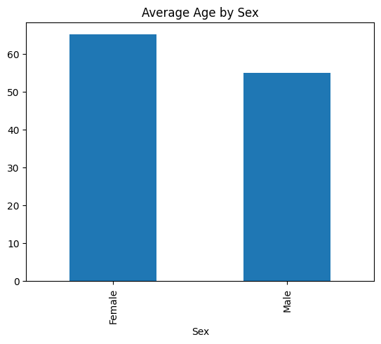

```python
# Importantly, we can visualize data directly from DataFrames, as they have built-in plotting methods.
age_by_sex.plot(kind='bar', title='Average Age by Sex')
```

We can visualize data stored in pandas DataFrames using pandas’ built-in plotting methods (as we did above). We can also create plots using Python’s `matplotlib` library, which we will explore in more detail next.

In fact, pandas uses `matplotlib` under the hood for its plotting functions. This means the visual style is very similar, and you can seamlessly combine pandas and matplotlib when creating figures.

```python
# Saving DataFrames: we can save DataFrames to various file formats, such as CSV (to_csv), Excel (to_excel), or JSON (to_json).

# For example, let's save the females data to a CSV file
data_females = data_people[data_people['Sex'] == 'Female']
data_females.to_csv('data/people-females.csv')  # Save the DataFrame to a CSV file
```

```python
## Exercise 2: Using the `data_people` DataFrame, compute the median age of women between 20 and 30 years old.
```

### 4.3. Matplotlib

**Matplotlib** is the go-to plotting library in Python. It lets you create a wide variety of plots, from line charts, to bar plots, to histograms, to scatter plots, and more.

Although pandas offers convenient built-in plotting functions, matplotlib gives you full control over every part of a figure: axes, labels, titles, colors, legends, and layout. This makes it especially useful when you want to fine-tune your visualizations or prepare figures for presentations and publications.

In practice, you’ll often use pandas to prepare your data and matplotlib to customize how it looks. Since pandas uses matplotlib internally, both libraries work together very naturally.

Below, we’ll explore a few basic examples to get familiar with matplotlib’s syntax and capabilities.

```python
# Always import matplotlib this way, pyplot is really the part we use most often
import matplotlib.pyplot as plt  # Import the matplotlib library for plotting
```

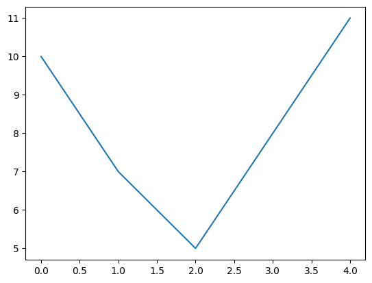

```python
# The most simple way to create a plot is to use the `plt.plot()` function for line plots.
x = [10, 7, 5, 8, 11]
plt.plot(x)  # Create a line plot of the data in list x
```

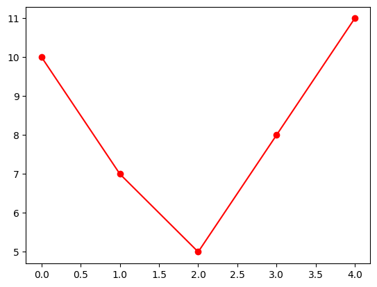

```python
# I think using markers makes it clearer, let's add them. Let's also change the color to red.
plt.plot(x, marker='o', color='red')
```

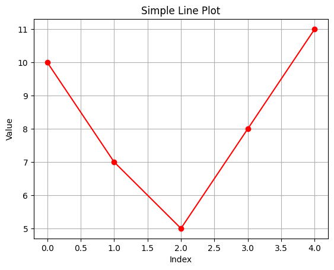

```python
plt.plot(x, marker='o', color='red')
# We can also add some optional customizations to improve the plot's appearance
plt.title("Simple Line Plot")  # Add a title to the plot
plt.xlabel("Index")  # Add x-axis label
plt.ylabel("Value")  # Add y-axis label
plt.grid(True)  # Add grid lines for better readability
```

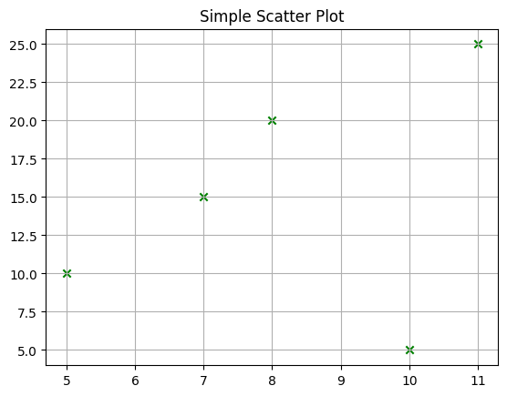

```python
# There are also other types of plots, such as scatter plots
y = [5, 15, 10, 20, 25]
plt.scatter(x, y, color='green', marker='x')  # Create a scatter plot with green 'x' markers
plt.title("Simple Scatter Plot")
plt.grid()
```

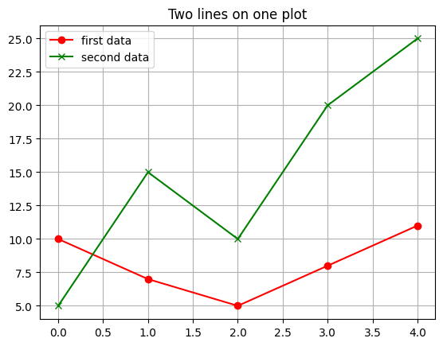

```python
# We can also overlay multiple data on the same figure (We can label each plot using the label parameter)
plt.plot(x, marker='o', color='red', label='first data')  # First plot
plt.plot(y, color='green', marker='x', label='second data')  # Second plot
plt.title("Two lines on one plot")
plt.legend() # Add a legend to distinguish the plots
plt.grid()
```

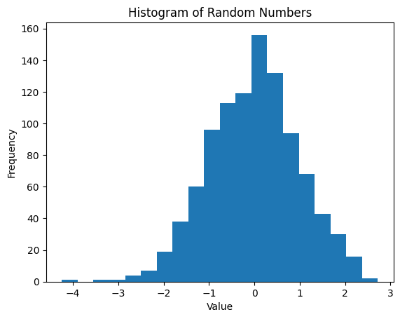

```python
# We can also create histograms to visualize the distribution of data
data = np.random.randn(1000)  # Generate 1000 random numbers from a normal distribution
plt.hist(data, bins=20) # Create a histogram with 20 bins
plt.title("Histogram of Random Numbers")
plt.xlabel("Value")
plt.ylabel("Frequency")
```

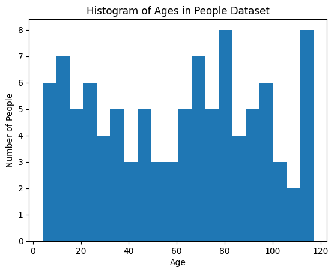

```python
# We can also plot pandas DataFrames data
plt.hist(data_people['Age'], bins=20)
plt.title("Histogram of Ages in People Dataset")
plt.xlabel("Age")
plt.ylabel("Number of People")
```

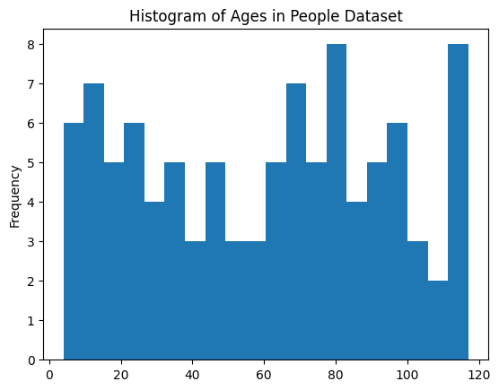

```python
# This is equivalent to:
data_people['Age'].plot(kind='hist', bins=20, title="Histogram of Ages in People Dataset")
```

## 5. Network analysis with `networkx`

In Python, the most widely used library for network analysis is **NetworkX**. It provides an intuitive interface for creating, manipulating, analyzing and visualizing networks. Graphs in networkx are of a special type `Graph` (for undirected networks) or `DiGraph` (for directed networks).

NetworkX lets us construct the same network in several ways, depending on the type of data we have. For instance

1. **From an adjacency matrix**  
   (for example, stored as a NumPy array)
2. **From an edgelist**  
   (for example, a pandas DataFrame with `source` and `target` columns)
3. **Directly from a list of edges**  
   (a Python list of tuples)

Once we have a network, we can apply several methods to analyze them. A few common methods in NetworkX are the following:

| Concept / Measure | Description | NetworkX Function |
| --- | --- | --- |
| **Node degree** | Number of neighbors a node has | `G.degree(n)` or `dict(G.degree())` |
| **Network density** | Fraction of possible edges that actually exist | `nx.density(G)` |
| **Average clustering coefficient** | Mean clustering across all nodes | `nx.average_clustering(G)` |
| **Degree assortativity** | Correlation between degrees of connected nodes | `nx.degree_assortativity_coefficient(G)` |
| **Shortest path (single pair)** | Length of shortest path between two nodes | `nx.shortest_path_length(G, u, v)` |
| **Average shortest path length** | Mean distance between all pairs of nodes | `nx.average_shortest_path_length(G)` |
| **Diameter** | Longest shortest path in the network | `nx.diameter(G)` |
| **Connected components** | Groups of nodes that are mutually reachable | `nx.connected_components(G)` |
| **Number of connected components** | Total number of components | `nx.number_connected_components(G)` |

Example: Let's consider the following very simple network with 5 nodes:

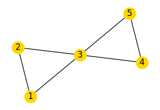

One way of representing this network is as a tuple $G = (V,E)$ of vertices $V$ and edges $E$, such that:

- **Nodes:** $V = [1, 2, 3, 4, 5]$
- **Edges:** $E = [(1, 2), (1, 3), (2, 3), (3, 4), (3, 5), (4, 5)]$

We can also represent it as an **edgelist** (where pandas DataFrames will come useful).

| source | target |
| --- | --- |
| 1 | 2 |
| 1 | 3 |
| 2 | 3 |
| 3 | 4 |
| 3 | 5 |
| 4 | 5 |

Finally, we can represent it as an **adjacency matrix** (where numpy arrays will come useful).

|  | 1 | 2 | 3 | 4 | 5 |
| --- | --- | --- | --- | --- | --- |
| **1** | 0 | 1 | 1 | 0 | 0 |
| **2** | 1 | 0 | 1 | 0 | 0 |
| **3** | 1 | 1 | 0 | 1 | 1 |
| **4** | 0 | 0 | 1 | 0 | 1 |
| **5** | 0 | 0 | 1 | 1 | 0 |

*Obs: This adjacency matrix is symmetric because the network is **undirected**.*

```python
# Let's import the networkx library (under shorthand name nx)
import networkx as nx
```

```python
# First, let's create our (undirected) network using a list of edges
edge_list = [(1, 2), (1, 3), (2, 3), (3, 4), (3, 5), (4, 5)]
G = nx.Graph()
G.add_edges_from(edge_list)

# Check that network has been created correctly
print("Nodes:", G.nodes())
print("Edges:", G.edges())
```

```
Nodes: [1, 2, 3, 4, 5]
Edges: [(1, 2), (1, 3), (2, 3), (3, 4), (3, 5), (4, 5)]
```

```python
# Now, let's do the same but using pandas DataFrame edgelists
pandas_edgelist = pd.DataFrame(edge_list, columns=["source", "target"])
print(pandas_edgelist)
print() # Print a blank line for better readability

# Construct the graph from the pandas edgelist
G = nx.from_pandas_edgelist(pandas_edgelist)

# Check that network has been created correctly
print("Nodes:", G.nodes())
print("Edges:", G.edges())
```

```
   source  target
0       1       2
1       1       3
2       2       3
3       3       4
4       3       5
5       4       5

Nodes: [1, 2, 3, 4, 5]
Edges: [(1, 2), (1, 3), (2, 3), (3, 4), (3, 5), (4, 5)]
```

```python
# Finally, let's create the same network using an adjacency matrix
adjacency_matrix = np.array([[0, 1, 1, 0, 0],
                              [1, 0, 1, 0, 0],
                              [1, 1, 0, 1, 1],
                              [0, 0, 1, 0, 1],
                              [0, 0, 1, 1, 0]])
# Construct the graph from the adjacency matrix
G = nx.from_numpy_array(adjacency_matrix, nodelist=[1, 2, 3, 4, 5])  # Specify nodelist to match original node labels

# Check that network has been created correctly
print("Nodes:", G.nodes())
print("Edges:", G.edges())
```

```
Nodes: [1, 2, 3, 4, 5]
Edges: [(1, 2), (1, 3), (2, 3), (3, 4), (3, 5), (4, 5)]
```

As you can see, all the constructions are equivalent

```python
# Now, we can calculate some basic properties of the network using Graph methods.
num_nodes = G.number_of_nodes()  # Get the number of nodes
num_edges = G.number_of_edges()  # Get the number of edges
degrees = dict(G.degree())  # Get the degree of each node as a dictionary
average_degree = sum(degrees.values()) / num_nodes  # Compute the average degree

print(f"Number of nodes: {num_nodes}")
print(f"Number of edges: {num_edges}")
print(f"Average degree: {average_degree:}")
print(f"Degrees of each node: {degrees}")
```

```
Number of nodes: 5
Number of edges: 6
Average degree: 2.4
Degrees of each node: {1: 2, 2: 2, 3: 4, 4: 2, 5: 2}
```

```python
# Not only the graph G has methods, but we can also use functions from the networkx library that take graphs as input.
density = nx.density(G)  # Compute the density of the graph G
diameter = nx.diameter(G)  # Compute the diameter of graph G
clustering_coefficient = nx.transitivity(G)  # Compute the clustering coefficient (or transitivity) of graph G
assortativity = nx.degree_assortativity_coefficient(G)  # Compute the degree assortativity coefficient of graph G

print(f"Density: {round(density, 2)}")
print(f"Diameter: {diameter}")
print(f"Average Clustering Coefficient: {round(clustering_coefficient, 2)}")
print(f"Degree Assortativity Coefficient: {round(assortativity, 2)}")
```

```
Density: 0.6
Diameter: 2
Average Clustering Coefficient: 0.6
Degree Assortativity Coefficient: -0.5
```

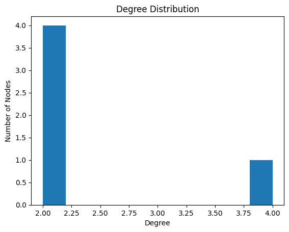

```python
# We can also visualize some of these properties using matplotlib
plt.hist( degrees.values() )
plt.title("Degree Distribution")
plt.xlabel("Degree")
plt.ylabel("Number of Nodes")
```

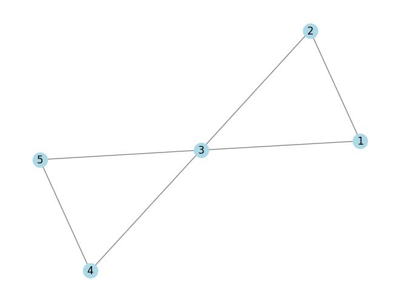

```python
# Finally, we can visualize the network itself with the `draw` function
nx.draw(G, with_labels=True, node_color='lightblue', edge_color='gray')
```

Now, let's read a real-world (although very simple) network from a file using networkx. It is located *data* folder and it's called *edges_moreno_grade2.csv*

This network represents relationships between pupils in a classroom. A **directed** edge exists if the source wants to sit next to the target. Each child can only choose two others. The network is freely available [here](https://networks.skewed.de/net/moreno_sociograms).

Given that the network is directed, we should use object `DiGraph` to create it.

```
   source  target
0       0       1
1       0       2
2       1       0
3       1       3
4       2       7
```

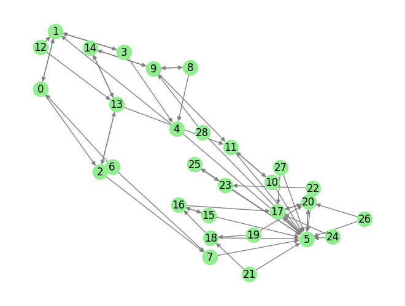

```python
# First, read the edgelist from the CSV file into a pandas DataFrame
edgelist_df = pd.read_csv('data/edges_moreno_grade2.csv')
print(edgelist_df.head())  # Display the first few rows of the edgelist DataFrame

# Construct the graph from the pandas edgelist
G = nx.from_pandas_edgelist(edgelist_df, create_using=nx.DiGraph) # Create a directed graph

# Visualize the network
nx.draw(G, with_labels=True, node_color='lightgreen', edge_color='gray')
```

Out of the blue, we can see that most children want to be friends of node 5, who is apparently very popular!

We can also observe that some edges are reciprocal, as some children choose each other as friends, while others are not, as some children choose friends that do not choose them back :(.

What else can you say about this network?

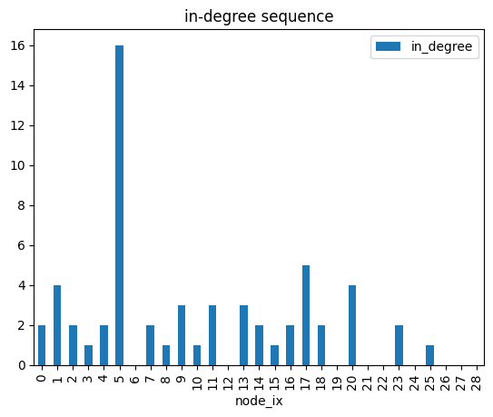

```python
# To get the degree of each node in a directed graph, we can use the in_degree and out_degree methods.
in_degrees = dict(G.in_degree())  # Get the in-degree of each node
out_degrees = dict(G.out_degree())  # Get the out-degree of each node

# Create a (sorted) DataFrame of the in-degrees
in_degrees = pd.DataFrame(in_degrees.items(), columns=['node_ix', 'in_degree'])
in_degrees = in_degrees.set_index('node_ix').sort_index()
in_degrees.plot(kind='bar', title='in-degree sequence')
```

```python
# We can check the in-neighbors (or predecessors) of a specific node using the neighbors() method
node = 5
node_predecessors = list(G.predecessors(node))  # Get the in-neighbors (predecessors) of the specified node
print(f"In-neighbors of node {node}:", node_predecessors)

# Similarly, we can check who doesn't consider node 5 as a friend (out-neighbors or successors)
nodes = G.nodes()
not_predecessors = [n for n in nodes if node not in node_predecessors]
print(f"Number of nodes that do not consider node {node} as a friend:", len(not_predecessors))
```

```
In-neighbors of node 5: [4, 7, 10, 11, 15, 17, 18, 20, 21, 22, 23, 24, 25, 26, 27, 28]
Number of nodes that do not consider node 5 as a friend: 29
```

```python
# There are some some nodes that are never considered as friends by anyone else. Let's find them.
unpopular_nodes = in_degrees[ in_degrees['in_degree'] == 0 ].index.values
print("Nodes that are not considered as friends by anyone else:", unpopular_nodes)
```

```
Nodes that are not considered as friends by anyone else: [ 6 12 19 21 22 24 26 27 28]
```

```python
# Exercise 3:
# 1. Is there a path from node 1 to node 10? In other words, is there anybody that considers 10 as a friend,
# and somebody else that considers that person as a friend, and so on, until we reach 1?
# 2. What is the shortest path from 1 to 10 (if it exists)?
# 3. What is its length?
# 4. Is there a reverse shortest path? Meaning, is there a path from node 10 to node 1?
# 5. If it exists, is it the same? What is its length?

# TIP: Check the networkx methods `has_path()` and `shortest_path()`
```

```python
# EXTRA: What is the longest shortest path across all nodes?
```

# Solutions

```python
# Solution for Exercise 1.
def most_popular(friendships):
    """Return the person who is considered a friend by the most people."""

    popularity = 0
    most_popular = 'None'

    for person in friendships:

        num_friends = len(consider_as_friend(friendships, person))
        if num_friends > popularity:
            popularity = num_friends
            most_popular = person

    print(f"The most popular person is {most_popular} with {popularity} friends.")
    return most_popular

most_popular(friendships)
```

```
The most popular person is Alice with 3 friends.
```

```
'Alice'
```

```python
# Solution for Exercise 2.
condition_women = (data_people['Sex'] == 'Female')
condition_age = (data_people['Age'] >= 20) & (data_people['Age'] <= 30)
median_age = data_people[condition_women & condition_age]['Age'].median()
print("Median age of women between 20 and 30 years old:", median_age)
```

```
Median age of women between 20 and 30 years old: 22.0
```

```python
# Solution to Exercise 3.

# First, check if there is a path from node 1 to node 10
if nx.has_path(G, source=1, target=10):
    print("There is a path from node 1 to node 10.")
    path_1_to_10 = nx.shortest_path(G, source=1, target=10)
    length_1_to_10 = len(path_1_to_10)
    print(f"Shortest path from 1 to 10: {path_1_to_10} with length {length_1_to_10}.")
else:
    print("There is no path from node 1 to node 10.")

print()
# Now, let's check the reverse path from node 10 to node 1
if nx.has_path(G, source=10, target=1):
    print("There is a path from node 10 to node 1.")
    path_10_to_1 = nx.shortest_path(G, source=10, target=1)
    length_10_to_1 = len(path_10_to_1)
    print(f"Shortest path from 10 to 1: {path_10_to_1} with length {length_10_to_1}.")
else:
    print("There is no path from node 10 to node 1.")
```

```
There is a path from node 1 to node 10.
Shortest path from 1 to 10: [1, 0, 2, 13, 11, 10] with length 6.

There is no path from node 10 to node 1.
```